# Climate_community

Volker Rudolf

2025-05-16

# Goals

We will examine how climate variables are linked to different aspects of community state transitions. THis is focused on frog calling data from 8 different ponds across 22 years. Climate data is taking from local weather stations, and frog calling data was converted to transition matrix indicating how community states (i.e. a specific combination of species) transition over time within a year.

## Load packages & data

Let’s load the community matrix and climate data (see “Community transition code.Rdm” and “Climate data preparation.Rdm”)

before we get into analysis lets look at correlation between network metrics

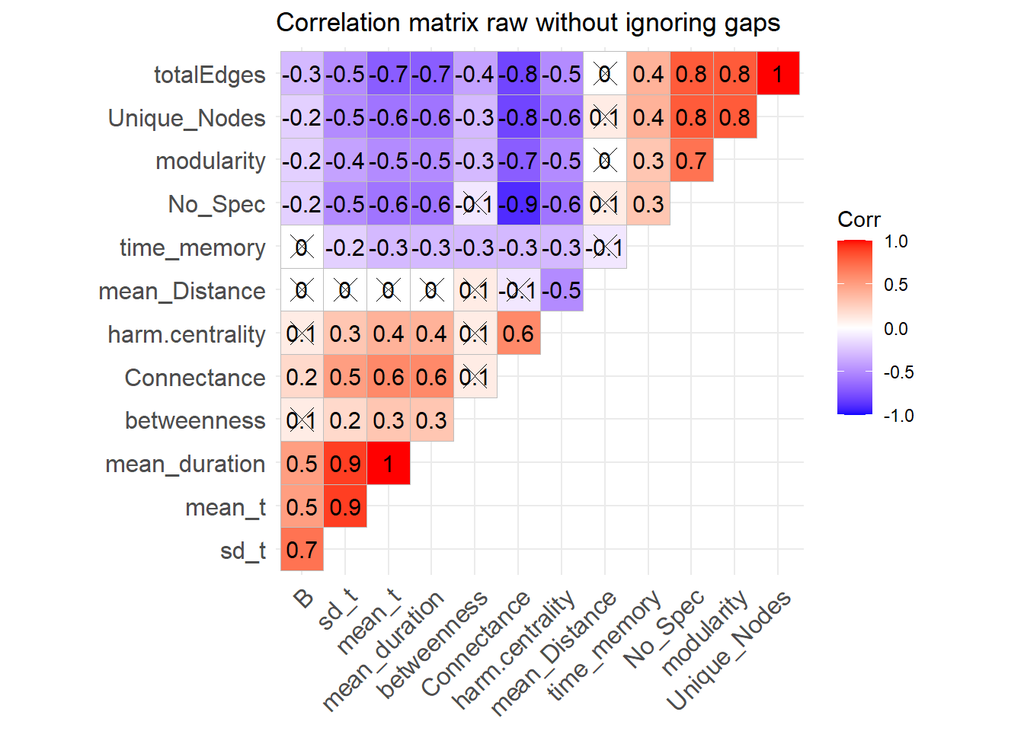

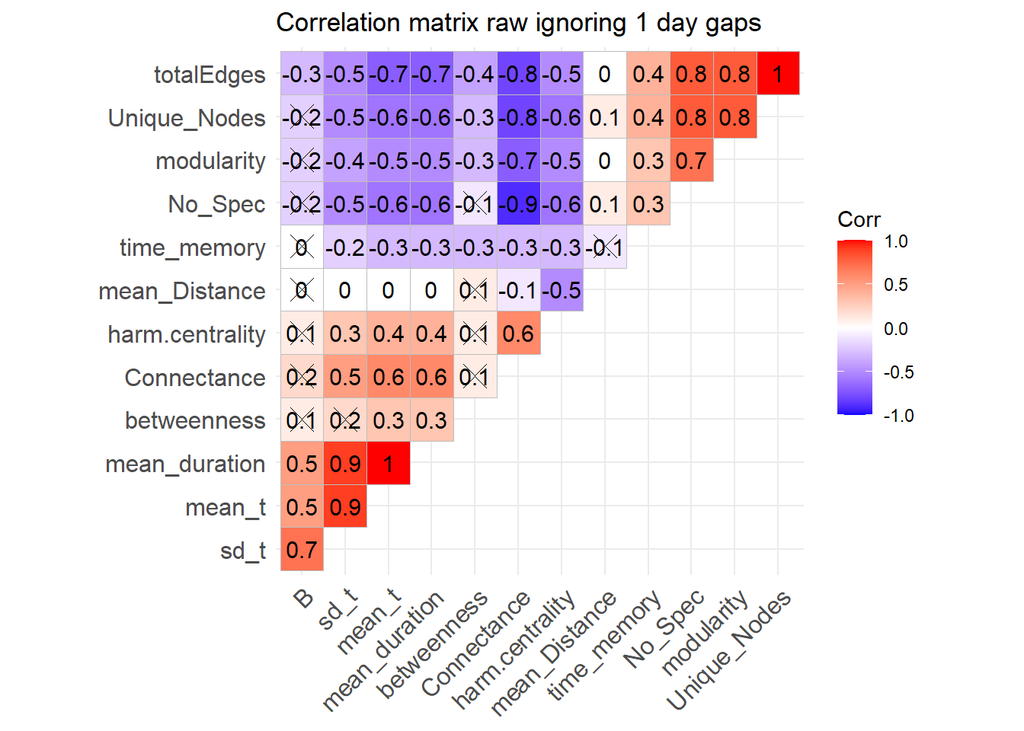

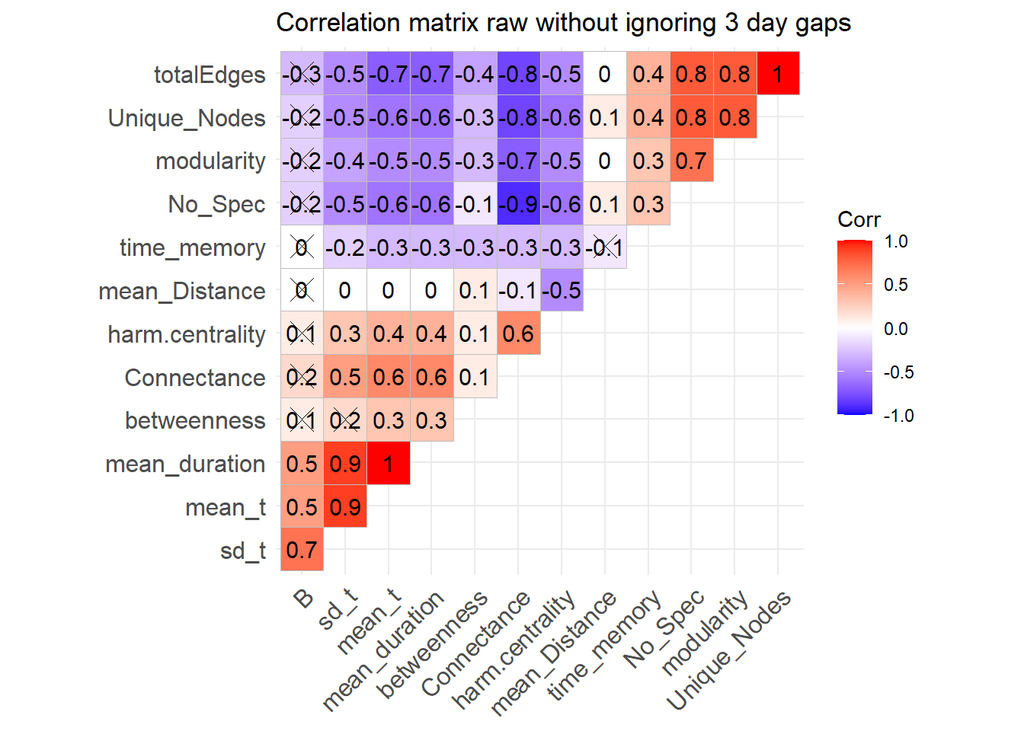

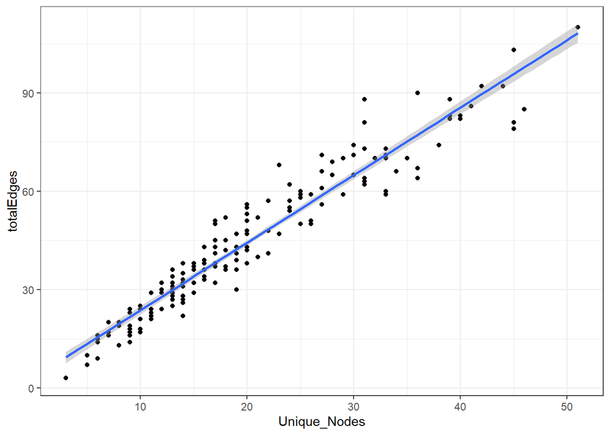

let’s see how those metrics fall out in a multidimensional space in a PCA to better understand they relationship

```
## Standard deviations (1, .., p=13):
##  [1] 2.57518083 1.36231971 1.17677904 0.98946427 0.83549854 0.71189606
##  [7] 0.53391904 0.51155938 0.45330549 0.35924423 0.20052897 0.14592808
## [13] 0.03185538
##
## Rotation (n x k) = (13 x 13):
##                         PC1         PC2         PC3         PC4         PC5
## Connectance     -0.32816442 -0.19430751 -0.04178331 -0.27627120 -0.01562102
## Unique_Nodes     0.34877824  0.20694166 -0.07209956  0.05329423  0.15170873
## totalEdges       0.35398334  0.10616790 -0.15880101  0.05549536  0.13265864
## modularity       0.31404960  0.17245899 -0.10849603  0.05341999  0.27968273
## mean_Distance    0.04117907  0.26054344  0.62621475 -0.50316077 -0.02705348
## harm.centrality -0.24890891 -0.33705304 -0.36062569  0.18910524  0.07603935
## betweenness     -0.12565915  0.03236601  0.45563883  0.67376920 -0.42870324
## No_Spec          0.32803813  0.20671556  0.02685734  0.30571651  0.01883164
## mean_t          -0.33019204  0.31570747 -0.02459195  0.03334527  0.12343526
## sd_t            -0.29349130  0.43773982 -0.14932207  0.04540978  0.10137401
## B               -0.16805257  0.47975775 -0.23401656  0.07248629 -0.05171470
## time_memory      0.16466550  0.18491766 -0.38403183 -0.26140635 -0.80533365
## mean_duration   -0.33039307  0.31223405 -0.01991867  0.04218944  0.11625434
##                         PC6         PC7         PC8         PC9         PC10
## Connectance     -0.05619268  0.19349642 -0.24035055  0.55981118 -0.600336865
## Unique_Nodes     0.08327269  0.45377413 -0.05034555  0.22604147  0.139609630
## totalEdges       0.06266847  0.48654503 -0.06078919  0.26619260  0.140937233
## modularity       0.18249397 -0.54107436 -0.65856887  0.10480359 -0.084868298
## mean_Distance   -0.09193588  0.24334172 -0.34079581 -0.30904348  0.010108176
## harm.centrality -0.03999046  0.37173114 -0.50134851 -0.50772429  0.032118528
## betweenness      0.04438350  0.07293189 -0.27285650  0.22650099  0.064936752
## No_Spec         -0.05538140  0.09812968  0.18522457 -0.35685144 -0.761648904
## mean_t           0.38091152  0.04569925  0.04221207 -0.06887419 -0.021089238
## sd_t             0.08178154  0.08784310  0.03479187  0.06437912  0.001417379
## B               -0.76255641 -0.06733076 -0.09968412  0.04552768  0.075761883
## time_memory      0.23798796 -0.01049726 -0.10656172 -0.07083663 -0.029260813
## mean_duration    0.38428618  0.01909097  0.04186965 -0.07588148 -0.023161092
##                        PC11        PC12         PC13
## Connectance     -0.05779151 -0.02706909  0.002166701
## Unique_Nodes    -0.21063797 -0.68853918 -0.007389394
## totalEdges       0.05863558  0.69188553  0.017723044
## modularity       0.02556910  0.01111438 -0.006405628
## mean_Distance    0.05089139  0.04778571  0.009010786
## harm.centrality  0.02251326 -0.04854387  0.005781431
## betweenness      0.02036275  0.01077651 -0.003766667
## No_Spec          0.01319397  0.02211653 -0.001110180
## mean_t          -0.27604613  0.09848607 -0.730955419
## sd_t             0.80302861 -0.13535194  0.068366720
## B               -0.26660803  0.06055396 -0.019404270
## time_memory     -0.01057095 -0.01474229 -0.002782635
## mean_duration   -0.39021323  0.09593187  0.678307764
```

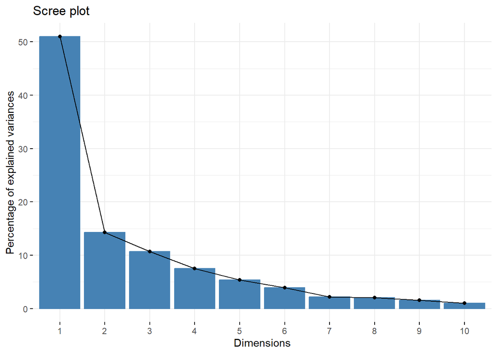

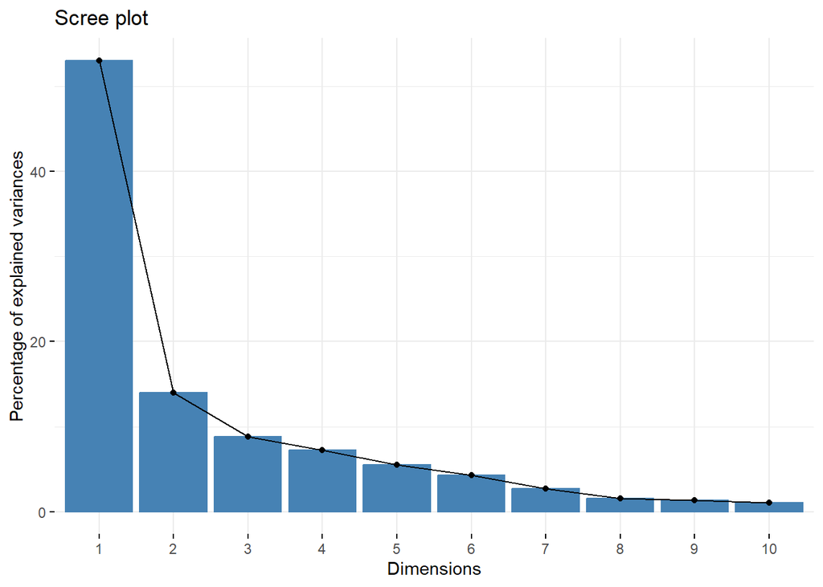

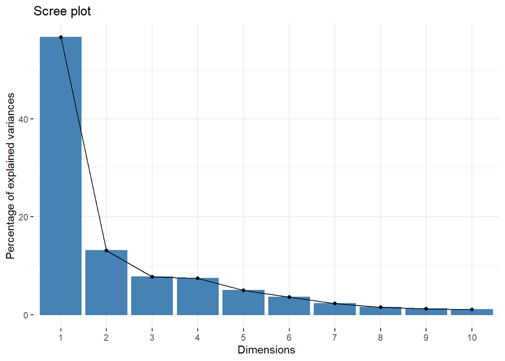

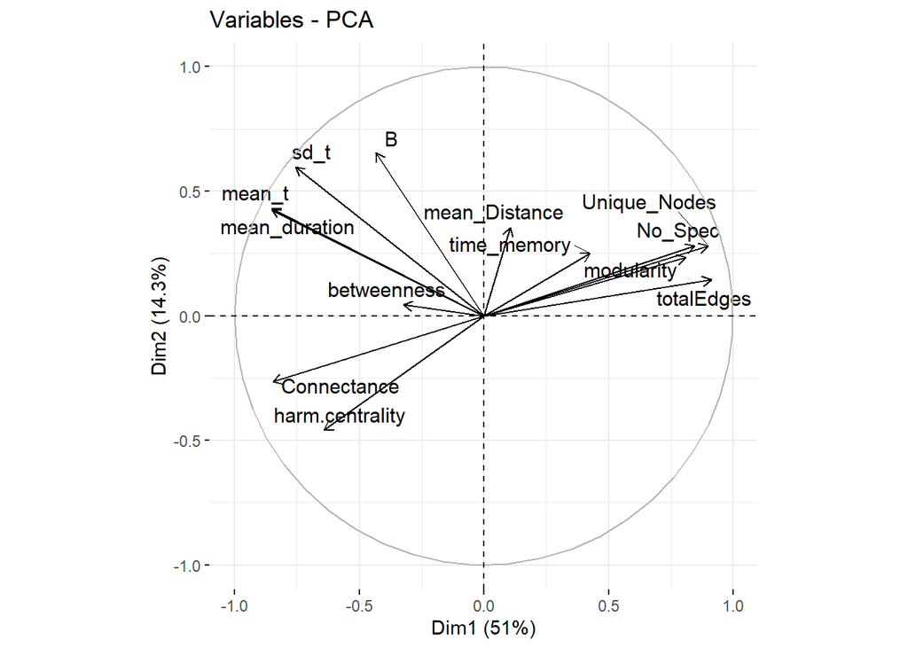

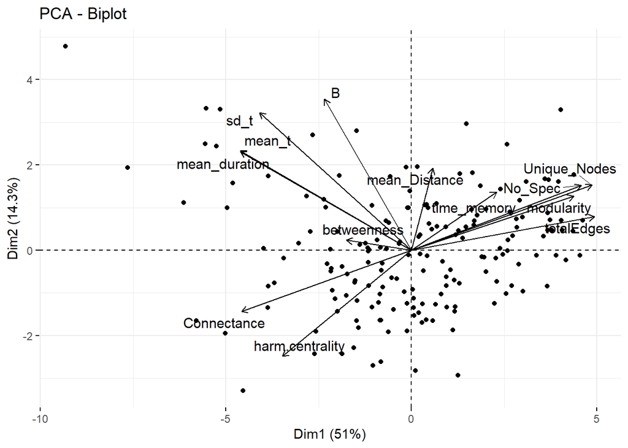

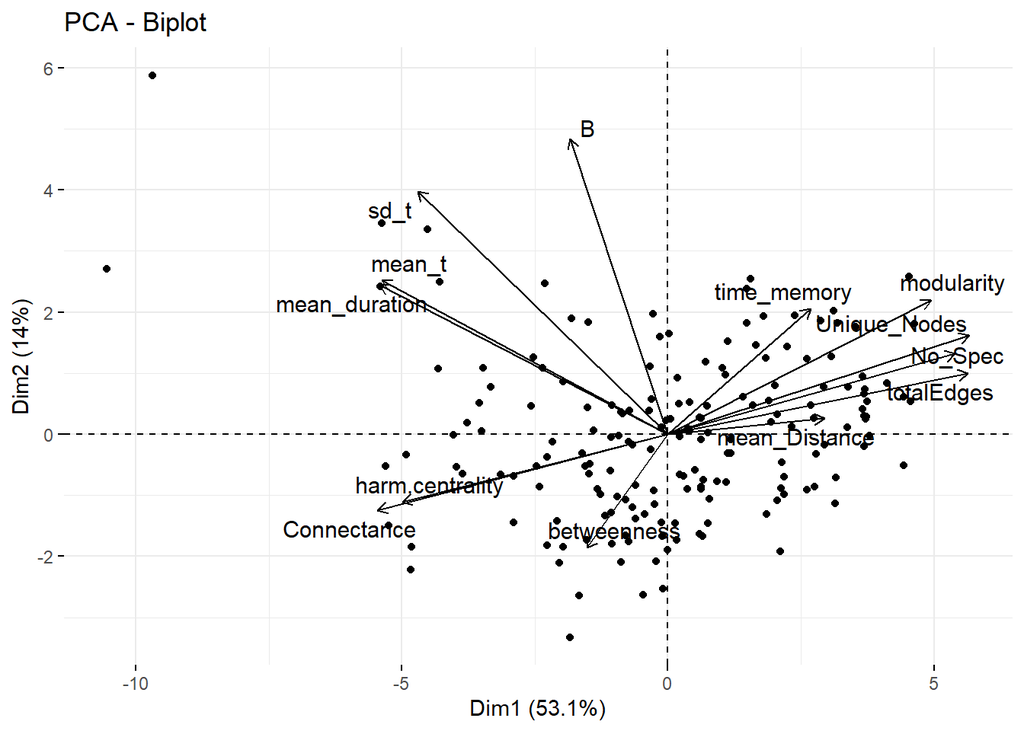

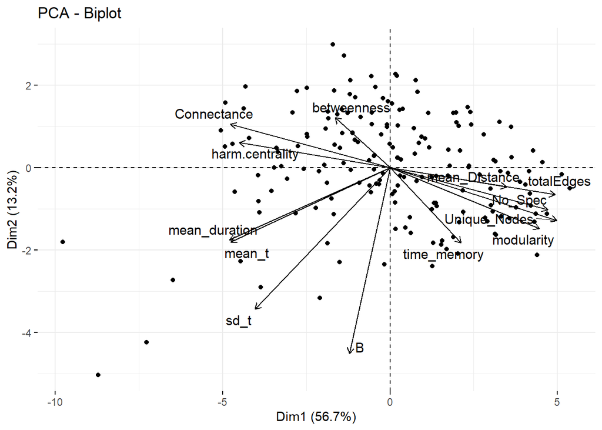

So two PCA are enough to explain a lot of variation in all these variables, and the first explains by far the most. It’s also interesting that the correlation between variables are robust and don’t change if we ignore small 1, 2, or 3 day gaps. Based on these relationship, we definitely want to keep No_Spec as covariate when we analyze the other metrics, and there is no point in including both totalEdges and Unique nodes since both are so correlated, and total Edges seems to be more different from No species than unique nodes and bit more informative on other aspects of the network.

#Network structure & climate analysis Ok so let’s analyze the network metrics and how they are linked to climate variables. We have to options: (1) use PC1 and PC2 in the analysis which strongly reduces the number of analyses we need. But it also is hard to interpret, and can miss more nuanced relationship of individual variables. So we will do both, PC based GLMM and individual network metric GLMM analyses

```
## boundary (singular) fit: see help('isSingular')
## boundary (singular) fit: see help('isSingular')
```

```
## [1] "Complete ANOVA Results for All Models:"
```

```
##                   Model                                    Effect Effect_Size
## 1            No_Species                                  meanMinT     -0.3241
## 2            No_Species                                  meanMaxT     -0.1218
## 3            No_Species                                  meanPrec      0.1874
## 4            No_Species                            burstinessRain      0.6048
## 5            No_Species                                     cycle      0.0638
## 6            No_Species                         meanMinT:meanMaxT     -0.5702
## 7            No_Species                         meanMinT:meanPrec     -0.3021
## 8            No_Species                         meanMaxT:meanPrec      0.2663
## 9            No_Species                   meanMinT:burstinessRain      0.7083
## 10           No_Species                   meanMaxT:burstinessRain     -0.6429
## 11           No_Species                   meanPrec:burstinessRain     -0.6055
## 12           No_Species                meanMinT:meanMaxT:meanPrec     -0.8937
## 13           No_Species          meanMinT:meanMaxT:burstinessRain     -0.3796
## 14           No_Species          meanMinT:meanPrec:burstinessRain      0.2553
```

[output cut: 291 more lines]

```
## [1] "P-values across all models:"
```

```
## # A tibble: 17 × 10
##    Effect              No_Species Betweenness Connectance Total_Edges Modularity
##    <chr>                    <dbl>       <dbl>       <dbl>       <dbl>      <dbl>
##  1 No_Spec                NA           0.666       0           0          0
##  2 burstinessRain          0.0393      0.202       0.536       0.005      0.174
##  3 cycle                   0.118       0.913       0.295       0.0811     0.0401
##  4 meanMaxT                0.831       0.0124      0.987       0.526      0.120
##  5 meanMaxT:burstines…     0.310       0.0124      0.0791      0.0417     0.0023
##  6 meanMaxT:meanPrec       0.360       0.0746      0.0435      0.0774     0.153
##  7 meanMaxT:meanPrec:…     0.277       0.506       0.333       0.742      0.462
##  8 meanMinT                0.0233      0.149       0.355       0.645      0.204
##  9 meanMinT:burstines…     0.0409      0.106       0.0225      0.0539     0.0009
## 10 meanMinT:meanMaxT       0.481       0.126       0.416       0.527      0.827
## 11 meanMinT:meanMaxT:…     0.852       0.439       0.860       0.331      0.831
## 12 meanMinT:meanMaxT:…     0.143       0.023       0.855       0.856      0.107
## 13 meanMinT:meanMaxT:…     0.314       0.456       0.987       0.586      0.338
## 14 meanMinT:meanPrec       0.818       0.014       0.603       0.435      0.242
## 15 meanMinT:meanPrec:…     0.902       0.276       0.0775      0.449      0.454
## 16 meanPrec                0.261       0.533       0.602       0.534      0.386
## 17 meanPrec:burstines…     0.405       0.0891      0.0328      0.0421     0.0415
## # ℹ 4 more variables: Mean_Distance <dbl>, Harmonic_Centrality <dbl>,
## #   Burstiness <dbl>, Memory <dbl>
```

```
## [1] "Effect sizes across all models:"
```

```
## # A tibble: 17 × 10
##    Effect              No_Species Betweenness Connectance Total_Edges Modularity
##    <chr>                    <dbl>       <dbl>       <dbl>       <dbl>      <dbl>
##  1 No_Spec                NA          -0.0021     -0.0391      0.205      0.0367
##  2 burstinessRain          0.605       0.0568     -0.0175     -0.0321     0.0194
##  3 cycle                   0.0638     -0.0004     -0.0016      0.0142     0.0057
##  4 meanMaxT               -0.122       0.057       0.0038     -0.0331    -0.055
##  5 meanMaxT:burstines…    -0.643       0.0739      0.0194     -0.250     -0.0644
##  6 meanMaxT:meanPrec       0.266      -0.0317     -0.0225      0.069      0.0177
##  7 meanMaxT:meanPrec:…     0.846       0.0516     -0.0287      0.0495     0.0434
##  8 meanMinT               -0.324      -0.0772     -0.0063      0.0526     0.0486
##  9 meanMinT:burstines…     0.708      -0.0336     -0.0324      0.186      0.103
## 10 meanMinT:meanMaxT      -0.570      -0.0555     -0.0101     -0.0208     0.0047
## 11 meanMinT:meanMaxT:…    -0.380      -0.016      -0.0034     -0.128      0.0112
## 12 meanMinT:meanMaxT:…    -0.894      -0.0177     -0.002      -0.0654     0.0056
## 13 meanMinT:meanMaxT:…    -1.04        0.0691     -0.0006     -0.112      0.0672
## 14 meanMinT:meanPrec      -0.302      -0.114       0.0046      0.0276    -0.0129
## 15 meanMinT:meanPrec:…     0.255       0.023       0.0243     -0.0344    -0.0327
## 16 meanPrec                0.187      -0.0095      0.007       0.0181    -0.0528
## 17 meanPrec:burstines…    -0.606       0.0129      0.0166     -0.123     -0.049
## # ℹ 4 more variables: Mean_Distance <dbl>, Harmonic_Centrality <dbl>,
## #   Burstiness <dbl>, Memory <dbl>
```

```
## [1] "Standard errors across all models:"
```

```
## # A tibble: 17 × 10
##    Effect              No_Species Betweenness Connectance Total_Edges Modularity
##    <chr>                    <dbl>       <dbl>       <dbl>       <dbl>      <dbl>
##  1 No_Spec                NA           0.0049      0.0019      0.0141     0.0048
##  2 burstinessRain          0.567       0.0509      0.0206      0.113      0.0385
##  3 cycle                   0.0407      0.0037      0.0015      0.0082     0.0028
##  4 meanMaxT                0.350       0.0314      0.0127      0.0697     0.0237
##  5 meanMaxT:burstines…     0.602       0.0541      0.0218      0.120      0.0409
##  6 meanMaxT:meanPrec       0.322       0.0288      0.0117      0.0641     0.0218
##  7 meanMaxT:meanPrec:…     0.819       0.0735      0.0297      0.163      0.0556
##  8 meanMinT                0.316       0.0283      0.0114      0.063      0.0214
##  9 meanMinT:burstines…     0.478       0.043       0.0174      0.0957     0.0326
## 10 meanMinT:meanMaxT       0.404       0.0363      0.0147      0.0807     0.0275
## 11 meanMinT:meanMaxT:…     0.578       0.0519      0.021       0.115      0.0392
## 12 meanMinT:meanMaxT:…     0.575       0.0517      0.0209      0.115      0.0392
## 13 meanMinT:meanMaxT:…     1.03        0.0926      0.0374      0.206      0.0701
## 14 meanMinT:meanPrec       0.480       0.043       0.0174      0.0956     0.0325
## 15 meanMinT:meanPrec:…     0.431       0.0386      0.0156      0.0858     0.0292
## 16 meanPrec                0.420       0.0377      0.0152      0.0837     0.0285
## 17 meanPrec:burstines…     0.459       0.0413      0.0167      0.0918     0.0313
## # ℹ 4 more variables: Mean_Distance <dbl>, Harmonic_Centrality <dbl>,
## #   Burstiness <dbl>, Memory <dbl>
```

```
## # A tibble: 17 × 10
##    Effect           Betweenness Connectance Total_Edges Modularity Mean_Distance
##    <chr>            <chr>       <chr>       <chr>       <chr>      <chr>
##  1 No_Spec          ""          "***"       "***"       "***"      ""
##  2 burstinessRain   ""          ""          "**"        ""         "*"
##  3 cycle            ""          ""          "."         "*"        ""
##  4 meanMaxT         "*"         ""          ""          ""         ""
##  5 meanMinT         ""          ""          ""          ""         ""
##  6 meanPrec         ""          ""          ""          ""         ""
##  7 meanMaxT:bursti… "*"         "."         "*"         "**"       ""
##  8 meanMaxT:meanPr… "."         "*"         "."         ""         ""
##  9 meanMinT:bursti… ""          "*"         "."         "***"      ""
## 10 meanMinT:meanMa… ""          ""          ""          ""         ""
## 11 meanMinT:meanPr… "*"         ""          ""          ""         ""
## 12 meanPrec:bursti… "."         "*"         "*"         "*"        ""
## 13 meanMaxT:meanPr… ""          ""          ""          ""         ""
## 14 meanMinT:meanMa… ""          ""          ""          ""         ""
## 15 meanMinT:meanMa… "*"         ""          ""          ""         ""
## 16 meanMinT:meanPr… ""          "."         ""          ""         ""
## 17 meanMinT:meanMa… ""          ""          ""          ""         ""
## # ℹ 4 more variables: Harmonic_Centrality <chr>, Burstiness <chr>,
## #   Memory <chr>, No_Species <chr>
```

Now let’s do it with the PC instead

```
## boundary (singular) fit: see help('isSingular')
## boundary (singular) fit: see help('isSingular')
## boundary (singular) fit: see help('isSingular')
```

```
## Analysis of Deviance Table (Type II Wald chisquare tests)
##
## Response: PC1
##                                   Chisq Df Pr(>Chisq)
## meanMinT                         0.1273  1    0.72126
## meanMaxT                         4.9368  1    0.02629 *
## meanPrec                         0.3147  1    0.57483
## burstinessRain                   4.3208  1    0.03765 *
## cycle                            1.6921  1    0.19333
## meanMinT:meanMaxT                2.3167  1    0.12799
## meanMinT:meanPrec                6.3328  1    0.01185 *
## meanMinT:burstinessRain          0.0540  1    0.81630
## meanMaxT:burstinessRain          0.0974  1    0.75496
## meanPrec:burstinessRain          5.8145  1    0.01589 *
## meanMinT:meanMaxT:burstinessRain 6.1518  1    0.01313 *
## ---
## Signif. codes:  0 '***' 0.001 '**' 0.01 '*' 0.05 '.' 0.1 ' ' 1
```

```
## Analysis of Deviance Table (Type II Wald chisquare tests)
##
## Response: PC1
##                                   Chisq Df Pr(>Chisq)
## meanMinT                         0.2339  1   0.628662
## meanMaxT                         3.5959  1   0.057923 .
## meanPrec                         0.2621  1   0.608684
## burstinessRain                   2.9811  1   0.084241 .
## cycle                            2.1041  1   0.146905
## meanMinT:meanMaxT                2.5027  1   0.113650
## meanMinT:meanPrec                6.6516  1   0.009907 **
## meanMinT:burstinessRain          0.0308  1   0.860655
## meanMaxT:burstinessRain          0.0388  1   0.843876
## meanPrec:burstinessRain          5.0924  1   0.024031 *
## meanMinT:meanMaxT:burstinessRain 5.1128  1   0.023750 *
## ---
## Signif. codes:  0 '***' 0.001 '**' 0.01 '*' 0.05 '.' 0.1 ' ' 1
```

```
## Analysis of Deviance Table (Type II Wald chisquare tests)
##
## Response: PC1
##                                   Chisq Df Pr(>Chisq)
## meanMinT                         0.3218  1   0.570552
## meanMaxT                         2.7863  1   0.095074 .
## meanPrec                         0.0627  1   0.802275
## burstinessRain                   3.2315  1   0.072237 .
## cycle                            2.7445  1   0.097590 .
## meanMinT:meanMaxT                2.8361  1   0.092169 .
## meanMinT:meanPrec                7.0549  1   0.007905 **
## meanMinT:burstinessRain          0.1717  1   0.678594
## meanMaxT:burstinessRain          0.2132  1   0.644287
## meanPrec:burstinessRain          4.7218  1   0.029783 *
## meanMinT:meanMaxT:burstinessRain 5.4917  1   0.019107 *
## ---
## Signif. codes:  0 '***' 0.001 '**' 0.01 '*' 0.05 '.' 0.1 ' ' 1
```

```
## boundary (singular) fit: see help('isSingular')
## boundary (singular) fit: see help('isSingular')
## boundary (singular) fit: see help('isSingular')
```

```
## Analysis of Deviance Table (Type II Wald chisquare tests)
##
## Response: PC2
##                                             Chisq Df Pr(>Chisq)
## meanMinT                                  12.4016  1  0.0004290 ***
## meanMaxT                                   5.6998  1  0.0169672 *
## meanPrec                                  19.0390  1  1.281e-05 ***
## burstinessRain                             1.1898  1  0.2753740
## cycle                                      7.3648  1  0.0066512 **
## meanMinT:meanMaxT                         13.9063  1  0.0001922 ***
## meanMinT:meanPrec                         11.4392  1  0.0007191 ***
## meanMaxT:meanPrec                          3.6262  1  0.0568751 .
## meanMinT:burstinessRain                   29.9757  1  4.375e-08 ***
## meanMaxT:burstinessRain                   12.0434  1  0.0005198 ***
## meanPrec:burstinessRain                   11.6643  1  0.0006371 ***
## meanMinT:meanMaxT:meanPrec                 0.0962  1  0.7564638
## meanMinT:meanMaxT:burstinessRain           0.2325  1  0.6296940
## meanMinT:meanPrec:burstinessRain           0.1204  1  0.7286213
## meanMaxT:meanPrec:burstinessRain           2.6821  1  0.1014837
## meanMinT:meanMaxT:meanPrec:burstinessRain 12.7785  1  0.0003506 ***
## ---
## Signif. codes:  0 '***' 0.001 '**' 0.01 '*' 0.05 '.' 0.1 ' ' 1
```

```
## Analysis of Deviance Table (Type II Wald chisquare tests)
##
## Response: PC2
##                                             Chisq Df Pr(>Chisq)
## meanMinT                                   8.1939  1   0.004203 **
## meanMaxT                                   6.3310  1   0.011865 *
## meanPrec                                  18.8761  1  1.395e-05 ***
## burstinessRain                             2.4591  1   0.116846
## meanMinT:meanMaxT                          9.2616  1   0.002340 **
## meanMinT:meanPrec                          4.5511  1   0.032898 *
## meanMaxT:meanPrec                          4.4812  1   0.034269 *
## meanMinT:burstinessRain                   25.0740  1  5.517e-07 ***
## meanMaxT:burstinessRain                   10.8100  1   0.001010 **
## meanPrec:burstinessRain                   10.4068  1   0.001255 **
## meanMinT:meanMaxT:meanPrec                 0.0089  1   0.924997
## meanMinT:meanMaxT:burstinessRain           0.5353  1   0.464369
## meanMinT:meanPrec:burstinessRain           0.0075  1   0.931099
## meanMaxT:meanPrec:burstinessRain           0.3066  1   0.579802
## meanMinT:meanMaxT:meanPrec:burstinessRain  3.3879  1   0.065676 .
## ---
## Signif. codes:  0 '***' 0.001 '**' 0.01 '*' 0.05 '.' 0.1 ' ' 1
```

```
## Analysis of Deviance Table (Type II Wald chisquare tests)
##
## Response: PC2
##                                             Chisq Df Pr(>Chisq)
## meanMinT                                   3.9511  1  0.0468417 *
## meanMaxT                                   7.4237  1  0.0064372 **
## meanPrec                                  12.8609  1  0.0003355 ***
## burstinessRain                             0.0411  1  0.8392649
## cycle                                      5.5126  1  0.0188802 *
## meanMinT:meanMaxT                         10.0739  1  0.0015038 **
## meanMinT:meanPrec                          4.8586  1  0.0275081 *
## meanMaxT:meanPrec                          3.2321  1  0.0722078 .
## meanMinT:burstinessRain                   20.0358  1  7.601e-06 ***
## meanMaxT:burstinessRain                    7.0828  1  0.0077828 **
## meanPrec:burstinessRain                    9.0415  1  0.0026392 **
## meanMinT:meanMaxT:meanPrec                 0.0689  1  0.7928817
## meanMinT:meanMaxT:burstinessRain           0.3635  1  0.5465682
## meanMinT:meanPrec:burstinessRain           0.4921  1  0.4829826
## meanMaxT:meanPrec:burstinessRain           1.2464  1  0.2642405
## meanMinT:meanMaxT:meanPrec:burstinessRain  8.1761  1  0.0042446 **
## ---
## Signif. codes:  0 '***' 0.001 '**' 0.01 '*' 0.05 '.' 0.1 ' ' 1
```

Let’s make some plots

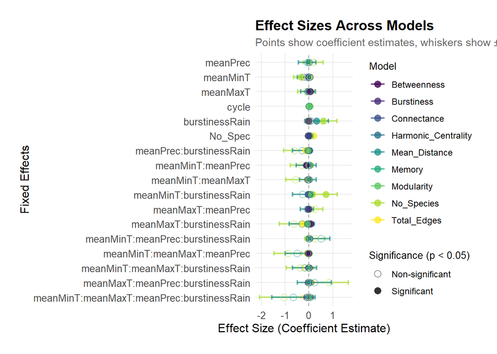

```
## [1] "Faceted plot:"
```

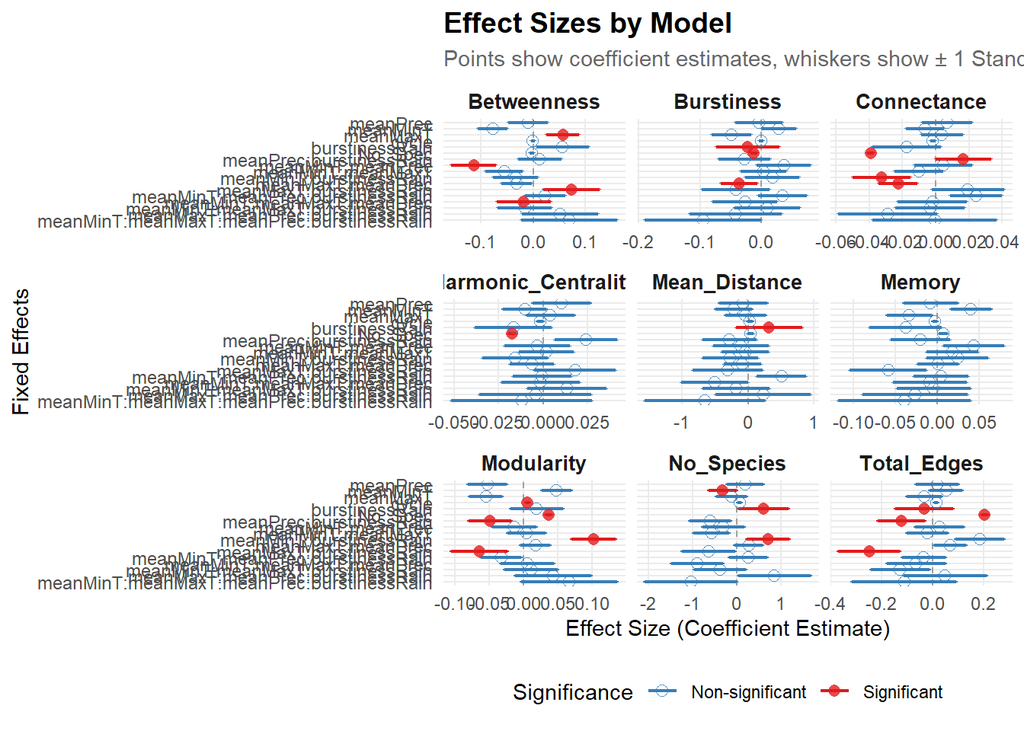

```
## [1] "Summary of effect sizes across models:"
```

```
## # A tibble: 17 × 8
##    Effect n_models mean_effect median_effect min_effect max_effect n_significant
##    <fct>     <int>       <dbl>         <dbl>      <dbl>      <dbl>         <int>
##  1 meanM…        9     -0.202        -0.0391    -1.04       0.0691             0
##  2 meanM…        9     -0.168        -0.0177    -0.894      0.0056             1
##  3 meanM…        9     -0.139        -0.0586    -0.643      0.0739             3
##  4 meanM…        9      0.124         0.0434    -0.0421     0.846              0
##  5 meanP…        9     -0.117        -0.0279    -0.606      0.0243             3
##  6 burst…        9      0.0973       -0.0167    -0.0378     0.605              4
##  7 meanM…        9      0.0868        0.023     -0.0344     0.508              0
##  8 meanM…        9      0.0763        0.0178    -0.270      0.708              3
##  9 meanM…        9     -0.0757       -0.0045    -0.380      0.0135             0
## 10 meanM…        9     -0.0744       -0.0101    -0.570      0.0178             0
## 11 meanM…        9     -0.0511       -0.0063    -0.324      0.0526             1
## 12 meanM…        9     -0.0478       -0.0033    -0.302      0.0435             1
## 13 meanM…        9     -0.0293       -0.0335    -0.122      0.057              1
## 14 No_Sp…        8      0.0274        0.0027    -0.0391     0.205              5
## 15 meanM…        9      0.0189       -0.0063    -0.0864     0.266              2
## 16 cycle         9      0.0123       -0.0003    -0.0027     0.0638             1
## 17 meanP…        9      0.0086       -0.0047    -0.0705     0.187              0
## # ℹ 1 more variable: prop_significant <dbl>
```

Look at extreme years

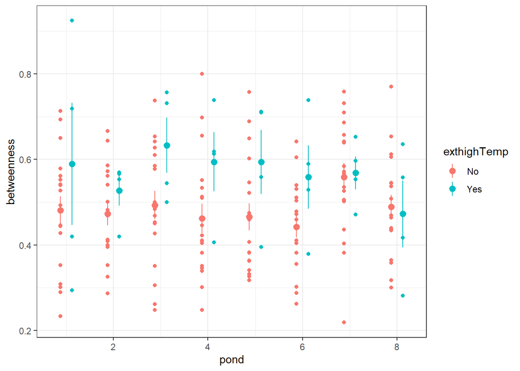

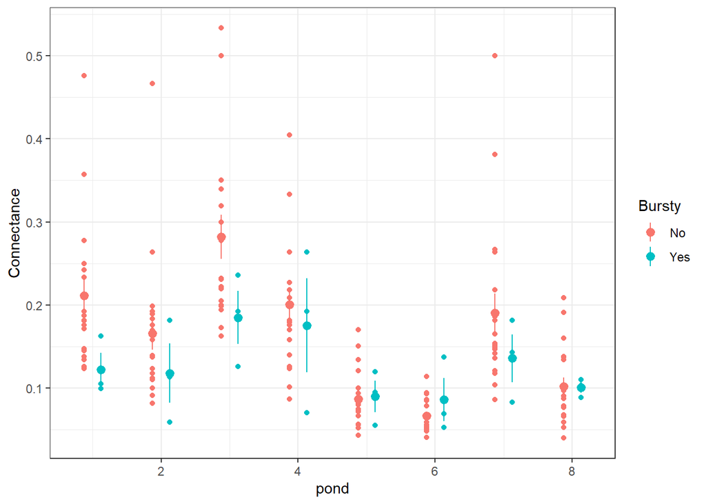

#Network vs Weather PCA analysis Instead of using all the different weather variables, we can also use the PCA of climate. Only two were important, which makes this a little bit easier

```
##
## boundary (singular) fit: see help('isSingular')
```

Table: P-values Across All Models

| Effect | No_Species | Betweenness | Connectance | Total_Edges | Modularity | Mean_Distance | Harmonic_Centrality | Burstiness | Memory |
| --- | --- | --- | --- | --- | --- | --- | --- | --- | --- |
| PC1 | 0.0163 | 0.0029 | 0.0176 | 0.0004 | 0.0025 | 0.3321 | 0.5546 | 0.6019 | 0.0935 |
| PC2 | 0.1158 | 0.1584 | 0.1145 | 0.4565 | 0.0239 | 0.1897 | 0.0167 | 0.6237 | 0.8094 |
| cycle | 0.3665 | 0.0229 | 0.2245 | 0.0027 | 0.0033 | 0.7021 | 0.3012 | 0.9057 | 0.3736 |

Table: Effect Size across all models

| Effect | No_Species | Betweenness | Connectance | Total_Edges | Modularity | Mean_Distance | Harmonic_Centrality | Burstiness | Memory |
| --- | --- | --- | --- | --- | --- | --- | --- | --- | --- |
| PC1 | -0.1209 | 0.0139 | 0.0063 | -0.0505 | -0.0114 | 0.0414 | 0.0012 | 0.0024 | -0.0061 |
| PC2 | -0.1472 | 0.0122 | 0.0078 | -0.0197 | -0.0159 | -0.1042 | 0.0087 | -0.0041 | -0.0016 |
| cycle | 0.0157 | -0.0037 | -0.0011 | 0.0148 | 0.0039 | 0.0057 | -0.0007 | 0.0002 | -0.0011 |

Table: Standard errors across all models

| Effect | No_Species | Betweenness | Connectance | Total_Edges | Modularity | Mean_Distance | Harmonic_Centrality | Burstiness | Memory |
| --- | --- | --- | --- | --- | --- | --- | --- | --- | --- |
| PC1 | 0.0503 | 0.0047 | 0.0026 | 0.0142 | 0.0038 | 0.0427 | 0.0020 | 0.0045 | 0.0037 |
| PC2 | 0.0936 | 0.0087 | 0.0049 | 0.0265 | 0.0070 | 0.0794 | 0.0037 | 0.0084 | 0.0068 |
| cycle | 0.0174 | 0.0016 | 0.0009 | 0.0049 | 0.0013 | 0.0148 | 0.0007 | 0.0016 | 0.0013 |

Table: Significance Patterns

[output not shown]